**Discrete Signal Processing (DSP):**  
**Discrete Signals**

Table of Contents

# 1. Discrete Time Signals

A **discrete-time signal** is a function defined over an integer-valued independent variable. We denote such a signal as:

$$ x[n] : \mathbb{Z} \rightarrow \mathbb{R} \ \text{or} \ \mathbb{C} $$

That is, the independent variable $n$ takes values in the set of integers $\mathbb{Z}$, and the signal value $x[n]$ is a real or complex number.

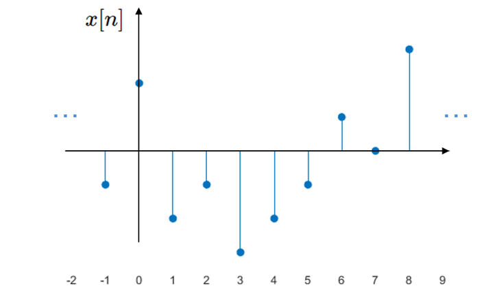

## 1.1. Plotting Real Signals

In MATLAB, different functions are used to visualize continuous-time and discrete-time signals:

- Continuous-Time Signals: Use the `plot` function to display continuous waveforms. This function connects data points with lines to approximate the appearance of a continuous signal.
- Discrete-Time Signals: Use the `stem` function to display discrete signals. This function emphasizes the fact that the signal is only defined at integer time indices.

MATLAB Code

$$x(t) = \sin(2\pi t)$$

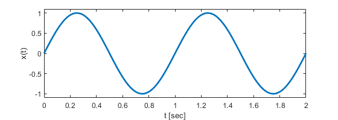

```matlab
%plot -s 560,200

t = 0:0.01:2;
x = sin(2*pi*t);

plot(t, x, 'linewidth', 2);
ylim([-1.1 1.1]);
xlabel('t [sec]');
ylabel('x(t)');
```

$$x[n] = \sin \left(\frac{2 \pi}{N}n \right)$$

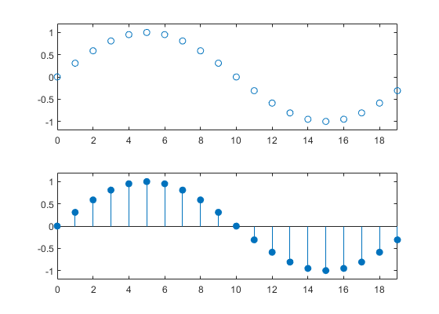

```matlab
%plot -s 560,400

N = 20;
n = 0:N-1;
x = sin(2*pi/N*n);

subplot(2,1,1)
plot(n,x,'o'), axis tight, ylim([-1.2, 1.2])
subplot(2,1,2)
stem(n,x,'filled'), axis tight, ylim([-1.2, 1.2])
```

# 2. Signal Properties

## 2.1. Finite- and Infinite-Length Signals

A discrete-time signal $x[n]$ may be either finite-length or infinite-length depending on its domain of definition:

- A signal is said to be of infinite length if it is defined for all integers:

$$ x[n], \quad n \in \mathbb{Z} $$

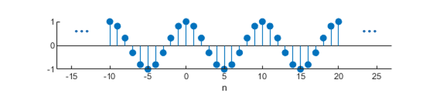

- A signal is said to be of finite length if it is defined only on a finite interval:

$$ x[n], \quad N_1 \leq n \leq N_2 $$

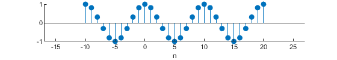

In practice, most physical signals are of finite duration, although infinite-length signals are often used in theory and analysis.

## 2.2. Periodic Signals

A discrete-time signal $x[n]$ is said to be periodic with period $N \in \mathbb{Z}^+$ if it satisfies the following condition for all $n \in \mathbb{Z}$ and all integers $m$:

$$ x[n + mN] = x[n] $$

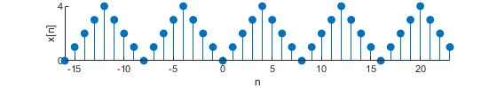

That is, the signal repeats itself every $N$ samples. Note the following important points:

- The period $N$ must be a positive integer
- A periodic signal is necessarily infinite in length
- If a signal is periodic, its entire structure is determined by a single period

Infinite-length and finite-length signals can be converted into one another through windowing and extension:

**Windowing (Truncation)**: An infinite-length signal $x[n]$ can be truncated to a finite-length signal $y[n]$ as follows:

$$ y[n] = \begin{cases} x[n], & N_1 \leq n \leq N_2 \\ 0, & \text{otherwise} \end{cases} $$

**Extension by Zero-Padding**: A finite-length signal can be extended to infinite length by zero-padding:

$$ y[n] = \begin{cases} 0, & n < N_1 \\ x[n], & N_1 \leq n \leq N_2 \\ 0, & n > N_2 \end{cases} $$

**Extension by Periodization**: Alternatively, a finite-length signal can be periodically extended to infinite length:

$$ \begin{align*} y[n] &= \sum_{m = -\infty}^{\infty} x[n - mN] \\ &=\cdots + x[n+N] + x[n] + x[n-N]+ \cdots \end{align*} $$

This operation is referred to as periodization and is central to the analysis of discrete Fourier transforms.

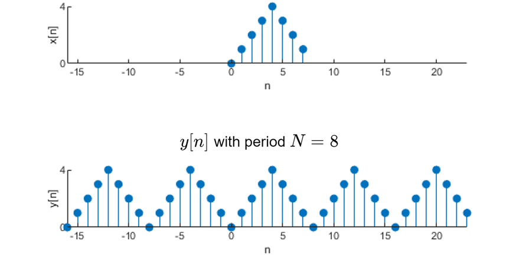

## 2.3. Modular Arithmetic and Periodic Indexing

**Modular Arithmetic**

Modular arithmetic with modulus $N$ effectively wraps the number line into a circular structure with $N$ distinct values:

$$ \cdots = (-12)_8 = (-4)_8 = 4 = 12 = 20 = \cdots $$

This arithmetic is inherently periodic and forms the basis for circular operations on signals.

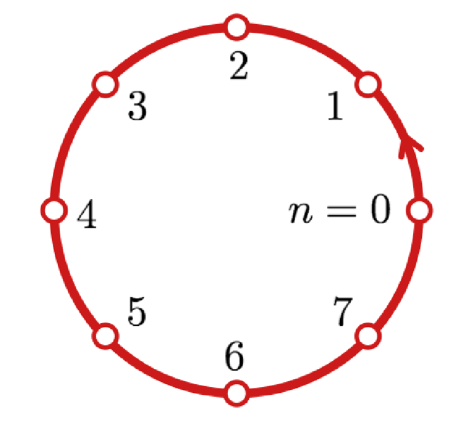

**Periodization Using Modular Indexing**

Let $x[n]$ be defined for $0 \leq n < N$. Then the periodic extension of $x[n]$ with period $N$ can be written compactly as:

$$ y[n] = x[(n)_N] $$

This expresses the idea that periodic signals live on a circle, in contrast to infinite-length signals which live on the infinite integer line.

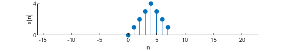

```matlab
%plot -s 560,100

N = 8;
n = 0:N-1;
x = [0 1 2 3 4 3 2 1];

stem(n,x,'filled');
xlabel('n'), ylabel('x[n]')
xlim([-16,23]),
yticks([0,4])
box('off')
```

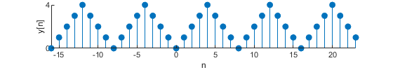

```matlab
%plot -s 560,100

%% periodic using mod
y = [];
n = -16:23;

for i = 1:length(n)
    y(i) = x(mod(n(i),N)+1);
end

stem(n,y,'filled'), axis tight
xlabel('n'), ylabel('y[n]')
yticks([0,4])
box('off')
```

## 2.4. Finite-Length vs. Periodic Signals

Finite-length and periodic signals are conceptually distinct, yet closely related:

- Every periodic signal is infinite in length, but contains only $N$ unique samples
- Every finite-length signal can be extended periodically
- Thus, in many contexts, we can treat finite-length and periodic signals interchangeably

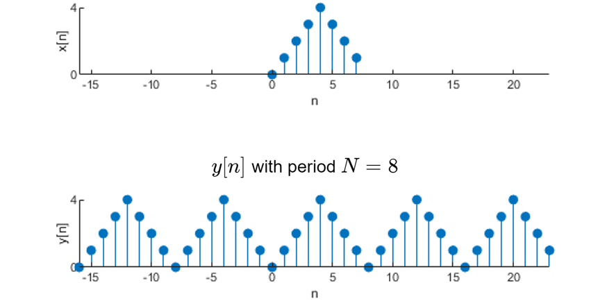

**Shifting Infinite-Length Signals**

Given an infinite-length signal $x[n]$, a shift by $m$ samples is defined as:

$$ x[n - m] $$

- If $m > 0$, this corresponds to a right shift (delay)
- If $m < 0$, this corresponds to a left shift (advance)

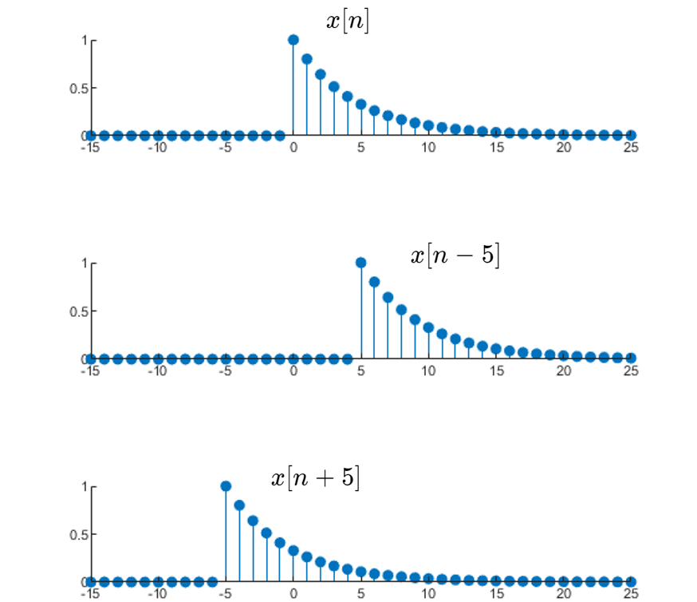

**Shifting Periodic Signals**

For a periodic signal $x[n]$ with period $N$, the shift operation must use modular arithmetic:

$$ y[n] = x[(n - m)_N] $$

This is known as a circular shift by $m$ samples.

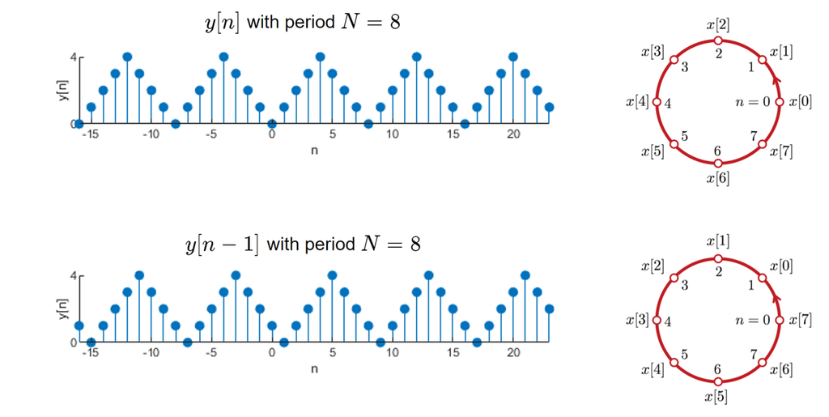

**Shifting Finite-Length Signals**

Consider two finite-length signals $x[n]$ and $y[n]$ defined for $0 \leq n < N$, and define:

$$ y[n] = x[n - 1] $$

This operation leads to ambiguity at the boundaries:

$$ \begin{aligned} y[0] &= \;? \\ y[1] &= x[0] \\ y[2] &= x[1] \\\\ &\vdots \\\\ y[N-1] &= x[N-2] \\ \;? &= x[N-1] \end{aligned} $$

To avoid information loss or invention, we assume that both signals are periodic with period $N$, leading to:

$$ y[n] = x[(n - 1)_N] $$

This defines a circular shift in the finite-length context.

**Circular Time Reversal**

For a periodic signal $x[n]$ of period $N$, the circular time reversal is defined as:

$$ y[n] = x[(-n)_N] $$

For example, with $N = 8$, the reversal yields:

$$ \begin{aligned} y[0] &= x[0] \\ y[1] &= x[7] \\ y[2] &= x[6] \\ y[3] &= x[5] \\ y[4] &= x[4] \\ y[5] &= x[3] \\ y[6] &= x[2] \\ y[7] &= x[1] \end{aligned} $$

This operation mirrors the signal around index $n = 0$ on a periodic domain.

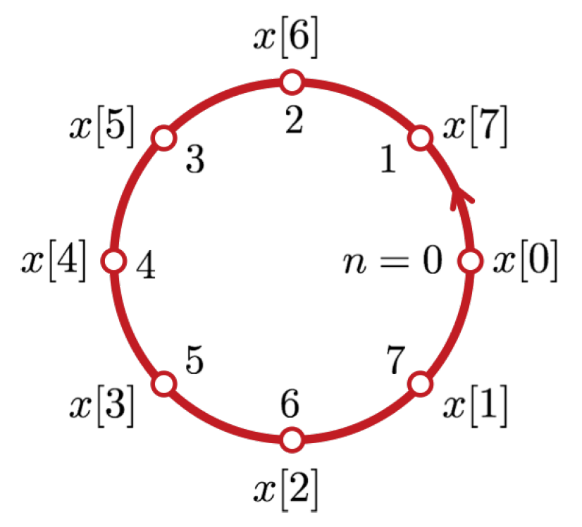

# 3. Key Discrete Signals

This section introduces fundamental discrete-time signals that are widely used in analysis, modeling, and implementation of digital systems.

## 3.1. Delta Function (aks Unit Impulse)

The unit impulse or delta function is defined as:

$$\delta[n] = \begin{cases}1 & n=0\\ 0 &\text{otherwise}\end{cases}$$

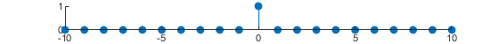

- A shifted delta function $\delta[n - m]$ equals 1 at $n = m$ and 0 elsewhere

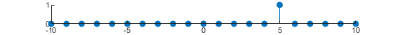

(MATLAB)

**Delta function: $\delta[n]$**

$$x[n]=\delta[n-n_0] \quad n_1 \leq n \leq n_2$$

`impseq(n0,n1,n2)`:

```
function [x,n] = impseq(n0,n1,n2)

% Generates x(n) = delta(n-n0); n1 <= n,n0 <= n2
% [x,n] = impseq(n0,n1,n2)

if ((n0 < n1) | (n0 > n2) | (n1 > n2))
    error('arguments must satisfy n1 <= n0 <= n2')
end

n = [n1:n2];
% x = [zeros(1,(n0-n1)), 1, zeros(1,(n2-n0))];
x = [(n-n0) == 0];
```

The delta function acts as a sampling operator. It isolates individual values from a signal.

**Sampling Property**:

Let $x[n]$ be a discrete-time signal. Then:

$$ y[n] = x[n] \delta[n - m] = x[m] \delta[n - m] $$

This identity expresses a fundamental property:

- The product $x[n] \delta[n - m]$ is nonzero only when $n = m$.
- At $n = m$, the value of the output is $x[m]$.
- Here, $x[m]$ is a constant scalar, and not a function of $n$.

This operation effectively picks out the value of $x[n]$ at index $n = m$ while setting all other values to zero.

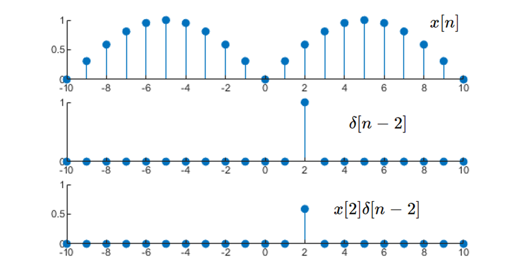

MATLAB code: A signal composed of delta functions:

$$x[n] = 2\delta[n+2] - \delta[n-4]$$

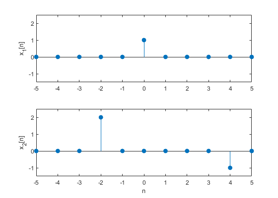

```matlab
%plot -s 560,400

% delta function

n = [-5:5];
x1 = impseq(0,-5,5);
x2 = 2*impseq(-2,-5,5)-impseq(4,-5,5);

subplot(2,1,1), stem(n,x1,'filled'), axis([-5,5,-1.5,2.5]), ylabel('x_1[n]');
subplot(2,1,2), stem(n,x2,'filled'), axis([-5,5,-1.5,2.5]), xlabel('n'), ylabel('x_2[n]');
```

## 3.2. Unit Step Function

The unit step function is defined as:

$$ u[n] = \begin{cases} 1, & n \geq 0 \\ 0, & n < 0 \end{cases} $$

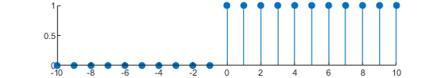

- The shifted step function $u[n - m]$ makes a step from 0 to 1 at $n = m$
- The step function is often used to construct piecewise-defined or time-limited signals

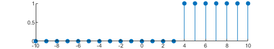

**Gating a Signal**:

The product of a signal and a unit step function truncates part of the signal:

$$ y[n] = x[n] u[n - m] $$

This sets all values of $x[n]$ to zero for $n < m$

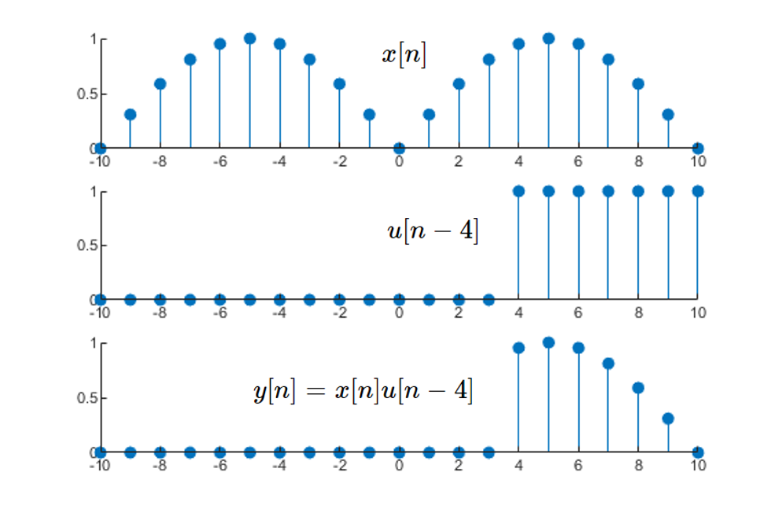

(MATLAB)

**Step function: $u[n]$**

$$x[n]=u[n-n_0] \quad n_1 \leq n \leq n_2$$

`stepseq(n0,n1,n2)`:

```
function [x,n] = stepseq(n0,n1,n2)
% Generates x(n) = u(n-n0); n1 <= n,n0 <= n2
% [x,n] = stepseq(n0,n1,n2)

if ((n0 < n1) | (n0 > n2) | (n1 > n2))
    error('arguments must satisfy n1 <= n0 <= n2')
end

n = [n1:n2];
% x = [zeros(1,(n0-n1)), ones(1,(n2-n0+1))];
x = [(n-n0) >= 0];
```

**Examples**:

- A finite rectangular pulse:

$$ x_1[n] = u[n] - u[n - 10] $$

- A decaying exponential starting at $n = 0$:

$$ x_2[n] = 0.9^n \, u[n] $$

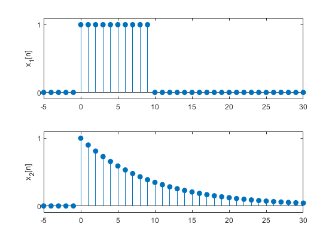

```matlab
%plot -s 560,400

% step function

n = -5:30;
x1 = stepseq(0,-5,30) - stepseq(10,-5,30);

x2 = 0.9.^n.*stepseq(0,-5,30);

subplot(2,1,1), stem(n,x1,'filled'), axis tight, ylim([-0.1, 1.1]), yticks([0,1]), ylabel('x_1[n]')
subplot(2,1,2), stem(n,x2,'filled'), axis tight, ylim([-0.1, 1.1]), yticks([0,1]), ylabel('x_2[n]')
```

## 3.3 Real Exponential Signals

A real exponential signal is defined as:

$$ x[n] = a^n, \quad n \in \mathbb{Z} $$

The shape of the signal depends on the value of $a$:

- If $a > 1$: the signal grows exponentially to the right

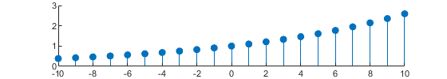

- If $0 < a < 1$: the signal decays exponentially

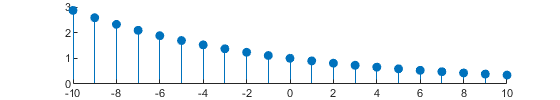